# Instruction Mannual

- 🌟 Author: Kohei Ozaki (Email: i@ho.lc)
- 📖 Lastupdate: Mon Jun 12 11:44:04 JST 2017

This document describes how to run XD_XD (Kohei) 's solution for Spacenet Challenge Round 2 with using nvidia-docker.

**Algorithm and Model Summary**: My final submission (18th submission, 17.csv) during the online submission phase is an averaging ensemble of three end-to-end U-Net models. The best individual model uses the combination of multispectral images and OpenStreetMap masks as the input layers of the neural network model.

## Directory Structure

My script on the docker container expects the following directory structure, which is the same one described on the official final testing guide.

```
/data
├── test
│   ├── AOI_2_Vegas_Test
│   ├── AOI_3_Paris_Test
│   ├── AOI_4_Shanghai_Test
│   └── AOI_5_Khartoum_Test
└── train
    ├── AOI_2_Vegas_Train
    ├── AOI_3_Paris_Train
    ├── AOI_4_Shanghai_Train
    └── AOI_5_Khartoum_Train
```

All working files for my solution will be stored on `/data/working`. For saving the training runtime, you can deploy working files and skip the training step. Those files are included in `kohei-solution-20170612_4.zip`. External resources (OSM shapefiles) are included in the docker image.

Here is the minimul list of files required on the inference step:

```
/data
└── working
     ├── images
     │    ├── v5
     │    │   ├── AOI_2_Vegas_immean.h5
     │    │   ├── AOI_2_Vegas_mulmean.h5
     │    │   ├── AOI_3_Paris_immean.h5
     │    │   ├── AOI_3_Paris_mulmean.h5
     │    │   ├── AOI_4_Shanghai_immean.h5
     │    │   ├── AOI_4_Shanghai_mulmean.h5
     │    │   ├── AOI_5_Khartoum_immean.h5
     │    │   ├── AOI_5_Khartoum_mulmean.h5
     │    │   ├── rgb_bandcutAOI_2_Vegas.csv
     │    │   ├── rgb_bandcutAOI_3_Paris.csv
     │    │   ├── rgb_bandcutAOI_4_Shanghai.csv
     │    │   └── rgb_bandcutAOI_5_Khartoum.csv
     │    │   ├── mul_bandcutAOI_2_Vegas.csv
     │    │   ├── mul_bandcutAOI_3_Paris.csv
     │    │   ├── mul_bandcutAOI_4_Shanghai.csv
     │    │   └── mul_bandcutAOI_5_Khartoum.csv
     │    ├── v12
     │    │   ├── AOI_2_Vegas_mulmean.h5
     │    │   ├── AOI_3_Paris_mulmean.h5
     │    │   ├── AOI_4_Shanghai_mulmean.h5
     │    │   ├── AOI_5_Khartoum_mulmean.h5
     │    └── v16
     │        └── .gitignore (placeholder)
     └── models
         ├── v9s
         │  ├── AOI_2_Vegas_30_val_weights.h5
         │  ├── AOI_2_Vegas_val_evalhist_th.csv
         │  ├── AOI_3_Paris_41_val_weights.h5
         │  ├── AOI_3_Paris_val_evalhist_th.csv
         │  ├── AOI_4_Shanghai_34_val_weights.h5
         │  ├── AOI_4_Shanghai_val_evalhist_th.csv
         │  ├── AOI_5_Khartoum_39_val_weights.h5
         │  └── AOI_5_Khartoum_val_evalhist_th.csv
         ├── v13
         │   ├── AOI_2_Vegas_21_val_weights.h5
         │   ├── AOI_2_Vegas_val_evalhist_th.csv
         │   ├── AOI_3_Paris_18_val_weights.h5
         │   ├── AOI_3_Paris_val_evalhist_th.csv
         │   ├── AOI_4_Shanghai_20_val_weights.h5
         │   ├── AOI_4_Shanghai_val_evalhist_th.csv
         │   ├── AOI_5_Khartoum_22_val_weights.h5
         │   └── AOI_5_Khartoum_val_evalhist_th.csv
         ├── v16
         │   ├── AOI_2_Vegas_21_val_weights.h5
         │   ├── AOI_2_Vegas_val_evalhist_th.csv
         │   ├── AOI_3_Paris_16_val_weights.h5
         │   ├── AOI_3_Paris_val_evalhist_th.csv
         │   ├── AOI_4_Shanghai_29_val_weights.h5
         │   ├── AOI_4_Shanghai_val_evalhist_th.csv
         │   ├── AOI_5_Khartoum_18_val_weights.h5
         │   └── AOI_5_Khartoum_val_evalhist_th.csv
         └── v17
              ├── AOI_2_Vegas_val_evalhist_th.csv
              ├── AOI_3_Paris_val_evalhist_th.csv
              ├── AOI_4_Shanghai_val_evalhist_th.csv
              └── AOI_5_Khartoum_val_evalhist_th.csv
```

**File Description**:

| Filename | Description |
| --- | --- |
| `<AOI_NAME>_mulmean.h5` | An mean image of multispectral images |
| `<AOI_NAME>_immean.h5` | An mean image of RGB images |
| `mul_bandcut<AOI_NAME>.csv` | percentile stats of multispectral images |
| `rgb_bandcut<AOI_NAME>.csv` | percentile stats of multispectral images |
| `<AOI_NAME>_val_weights.h5` | A model weight of trained network model |
| `<AOI_NAME>_val_evalhist_th.csv` | A result of parameter optimization on validation set |

Please be aware of the remaining disk space. The size of Docker image grows up to **9.3 GB**. When the disk space is empty during the training step, some working file will be broken.

## (Optional) Create a spot instance

```
## (Optional) Create a spot instance
## In this example, I request a spot instance with my AMI already installed with nvidia-docker.
macbook$ docker-machine create \
    --driver amazonec2 \
    --amazonec2-region us-west-2 \
    --amazonec2-zone b \
    --amazonec2-ami ami-3d77115d \
    --amazonec2-instance-type p2.xlarge \
    --amazonec2-root-size 30 \
    --amazonec2-vpc-id vpc-c3444da1 \
    --amazonec2-access-key *********** \
    --amazonec2-secret-key *********** \
    --amazonec2-request-spot-instance \
    --amazonec2-security-group spacenet2-group \
    --amazonec2-spot-price 0.9 \
    aws01
macbook$ docker-machine scp kohei-solution-20170612_4.zip aws01:~/
macbook$ docker-machine ssh aws01

## This solution consumes huge amount of disk space.
## Mounting a large magnet volume (> 1 TB) is recommended when you run the instruction of training step from scratch.
ubuntu@aws01:~$ sudo mount /dev/xvdf /data
```

## Build Docker Image

```
## 1. Extract my solution archive.
ubuntu@aws01:~$ unzip kohei-solution-20170612_4.zip
ubuntu@aws01:~$ cd kohei-solution

## 2. Build docker image (image name: kohei-sol)
ubuntu@aws01:~/kohei-solution$ sudo docker build -t kohei-sol .
(snip)
Successfully built 691ea5072dd3
Successfully tagged kohei-sol:latest

## 3. Run and exit a container (container name: kohei-container)
$ sudo nvidia-docker run \
    --name kohei-container \
    -v /data:/data \
    -ti kohei-sol \
    bash

root@xxxxxxxx:~# exit
```

## Instructions for Inference Step (with using trained models)

For inference step, the preprocessed files and trained model weights must be stored on `/data/working`. This solution can skip the training step when the files of the minimum requirements described on the above are deployed on `/data/working`.

```
## 0. Copy working files including trained model weights into the container (kohei-container)
$ sudo docker cp working kohei-container:/data/

## 1. Start the docker container by nvidia-docker
$ sudo nvidia-docker start -a kohei-container -i

## 2. Inference
## (the prefix of directory name on the datapath must be one of AOI_2_Vegas, AOI_3_Paris, AOI_4_Shanghai and AOI_5_Khartoum.)
root@xxxxxxxx:~$ ./test.sh \
    /data/test/AOI_2_Vegas_Test \
    /data/test/AOI_3_Paris_Test \
    /data/test/AOI_4_Shanghai_Test \
    /data/test/AOI_5_Khartoum_Test \
    v17.csv
>>> PREPROCESSING STEP
>>> python v5_im.py preproc_test /data/test/AOI_2_Vegas_Test
2017-05-27 18:47:48,303 INFO preproc_test for AOI_2_Vegas
2017-05-27 18:47:48,303 INFO Generate IMAGELIST for inference
2017-05-27 18:47:48,313 INFO Generate RGB_STORE (test)
2017-05-27 18:47:48,318 INFO prep_rgb_image_store_test for AOI_2_Vegas
2017-05-27 18:47:48,319 INFO Image store file: /data/working/images/v5/test_AOI_2_Vegas_im.h5
(snip)
2017-05-27 21:35:50,534 INFO Prediction phase: AOI_5_Khartoum
100%|███████████████████████████████████████| 336/336 [00:06<00:00, 55.21it/s]
100%|███████████████████████████████████████| 3024/3024 [01:21<00:00, 17.50it/s]
100%|███████████████████████████████████████| 3024/3024 [01:27<00:00, 27.61it/s]
2017-05-27 21:39:58,446 INFO Averaging
2017-05-27 21:40:20,217 INFO >>>> Test proc for AOI_5_Khartoum ... done
>>> MERGE INFERENCE RESULTS
>>> python merge.py /data/test/AOI_2_Vegas_Test /data/test/AOI_3_Paris_Test /data/test/AOI_4_Shanghai_Test /data/test/AOI_5_Khartoum_Test v17.csv

## 3. Exit bash
root@xxxxxxxx:~$ exit

## 4. Copy a submission file to docker host
$ sudo nvidia-docker cp kohei-container:/root/v17.csv .
```

It seems the time cost is **about 3 hours for inference step**.

## Instructions for Training Step from scratch

`train.sh` is the script to train models **from scratch**. Note that this script removes /data/working at first step.

```
## 1. Run Container (container name: kohei-container)
$ sudo nvidia-docker start -a kohei-container -i

## 2. Training
root@xxxxxxxx:~$ ./train.sh \
    /data/train/AOI_2_Vegas_Train \
    /data/train/AOI_3_Paris_Train \
    /data/train/AOI_4_Shanghai_Train \
    /data/train/AOI_5_Khartoum_Train
```

## Appendix: Performance Comparison

**My lightweight model v9s outperforms the 2nd place competitor's model** on provisonal stage. It doesn't requires OpenStreetMap and time-consuming training time.

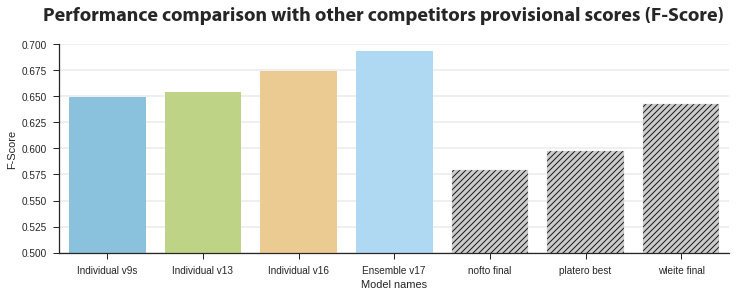

```python
doc_plot.performance_comparison()
```

## Appendix: Time Cost Analysis

**p2.xlarge is 2 times slower** than a personal PC with GeForce 1080. It's amazing how quickly GPU is evolving! Tesla K80 on p2.xlarge was released in 2014. My 17th submission (best one. v18.csv. not final) requires 6 models and scores over 70k on provisonal phase. However, it may exceed the time limitation described on the final test guide. This is the reason why I choosed 18th submission (ensemble of 3 models, v17.csv) as final one.

[figure not shown]

```python
doc_plot.time_cost_analysis()
```

## Reference

- "Spacenet 2. Final testing guide" https://docs.google.com/document/d/1-Jme2OQEMkegpYbZ10-iqyBJQ9ZWE2ntazWiSanAAbA/edit#